# R color

Jong-June Jeon

May, 2018

## Palette

## R colors

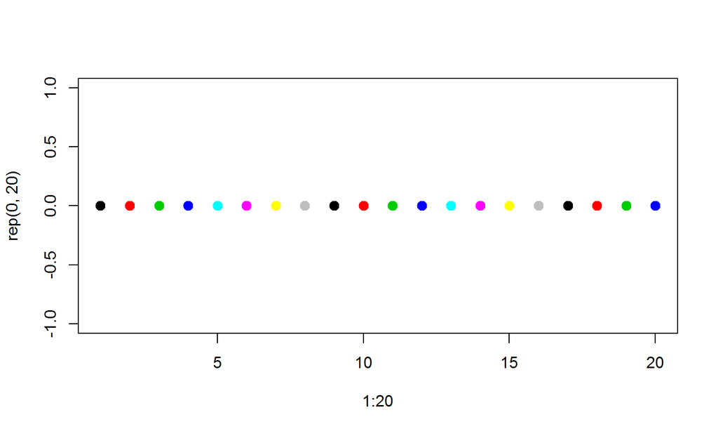

```r
plot(1:20, y=rep(0,20), col = 1:20, cex = 2, pch = 20 )
```

## R colors

- 16진법 표기를 사용한다. (0 ~ 9, A ~ F)
- 기본적으로 빨간색, 초록색, 파란색을 지정하며, 16진법으로 2개씩 표현한다. 즉, 기본 색상 별로 각각 256개로 표현 할 수 있다. (#rrggbb)
- 그러므로 $256 \times 256 \times 256 = 2^{24}$개의 색상이 표현된다. : 24 bit colors.
- 또한, 24 bit colors에 투명도(256 level)를 추가하면 32 bit color system이 된다.(#rrggbbaa)

## colors()

- Basic colors

```r
head(colors())
```

```
## [1] "white"         "aliceblue"     "antiquewhite"  "antiquewhite1"
## [5] "antiquewhite2" "antiquewhite3"
```

```r
tail(colors())
```

```
## [1] "yellow"      "yellow1"     "yellow2"     "yellow3"     "yellow4"
## [6] "yellowgreen"
```

## colors()

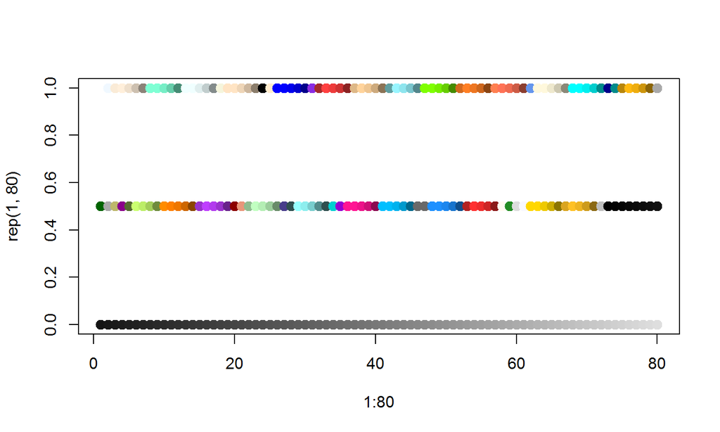

```r
    mycol = colors()
    plot(1:80, y=rep(1,80), col = mycol[1:80], cex = 2, pch = 20,
         ylim = c(0,1) )
    points(1:80, y=rep(0.5,80), col = mycol[81:160], cex = 2, pch = 20 )
    points(1:80, y=rep(0,80), col = mycol[161:240], cex = 2, pch = 20 )
```

## colors()

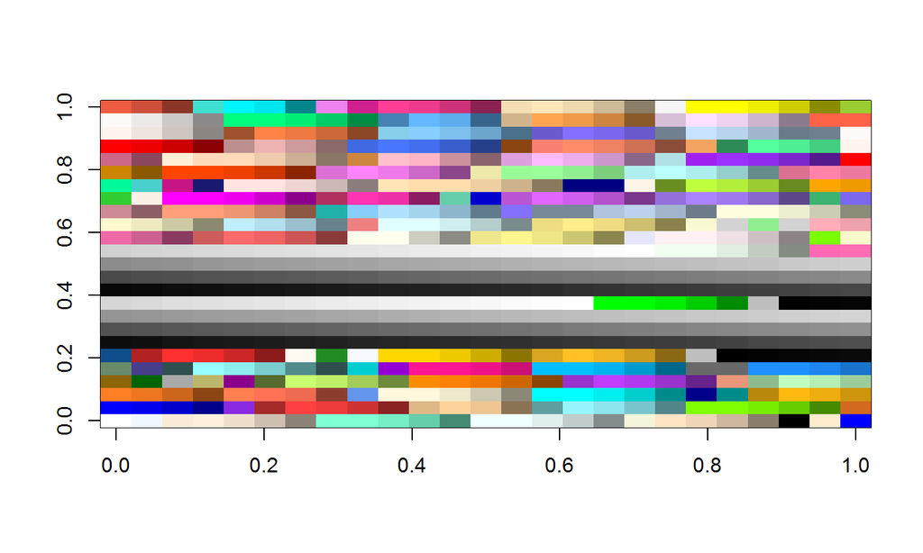

```r
mycol = colors()
image(matrix(1:25^2,25,25), col = mycol)
```

## rgb function

- rgb(red, green, blue, maxColorValue, alpha)
- red, green, blue : 기본으로 0 ~ 1 사이의 값을 사용한다.
- `maxColorValue = 255` 으로 세팅하게 되면 0 ~255 사이의 값으로 사용할 수 있다.
- alpha : opacity(투명도)

```r
rgb(10, 4, 23, maxColorValue = 255, alpha = 10)
```

```
## [1] "#0A04170A"
```

```r
col2rgb('lightblue')
```

```
##       [,1]
## red    173
## green  216
## blue   230
```

## hue color system

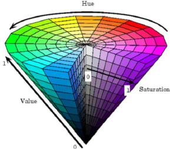

- 색상들은 콘 모양으로 볼수 있다.
- 바깥쪽으로 갈수록 채도가 높은 색이다.
- 위쪽으로 갈수록 밝기는 증가하게 된다.

## hcl function

- hcl(h, c, l, alpha)
- h: colors(색상), c: saturation(채도), l: brightness(밝기), alpha: opacity(투명도)
- h$\in [0,360]$: 0~120(red), 120~240(green), 240~360(blue)
- l $\in [0, 100]$, alpha $\in [0,1]$
- c의 범위는 h와 l의 값에 따라 변한다. (즉, 색상은 채도, 밝기에 의존한다.)

```r
hcl(h = 0, c = 35, l = 85, alpha = 0.1)
```

```
## [1] "#FFC5D01A"
```

## hsv function

- hsv(h, s, v, alpha)
- h: color(색상), s: satulation(채도), v: brightness(밝기), alpha: opacity(투명도)
- h, s, v, alpha $\in [0,1]$

```r
hsv(0.3, 0.5, 0.1, alpha = 0.4)
```

```
## [1] "#0F1A0D66"
```

## grDevices, colorRamps Packages

- cm.colors, topo.colors, terrain.colors, heat.colors, rainbow
- cm, topo, terrain, heat : n (색상의 수), alpha (투명도)

```r
heat.colors(4, alpha = 1)
```

```
## [1] "#FF0000FF" "#FF8000FF" "#FFFF00FF" "#FFFF80FF"
```

```r
topo.colors(4, alpha = 1)
```

```
## [1] "#4C00FFFF" "#00E5FFFF" "#00FF4DFF" "#FFFF00FF"
```

## grDevices, colorRamps Packages

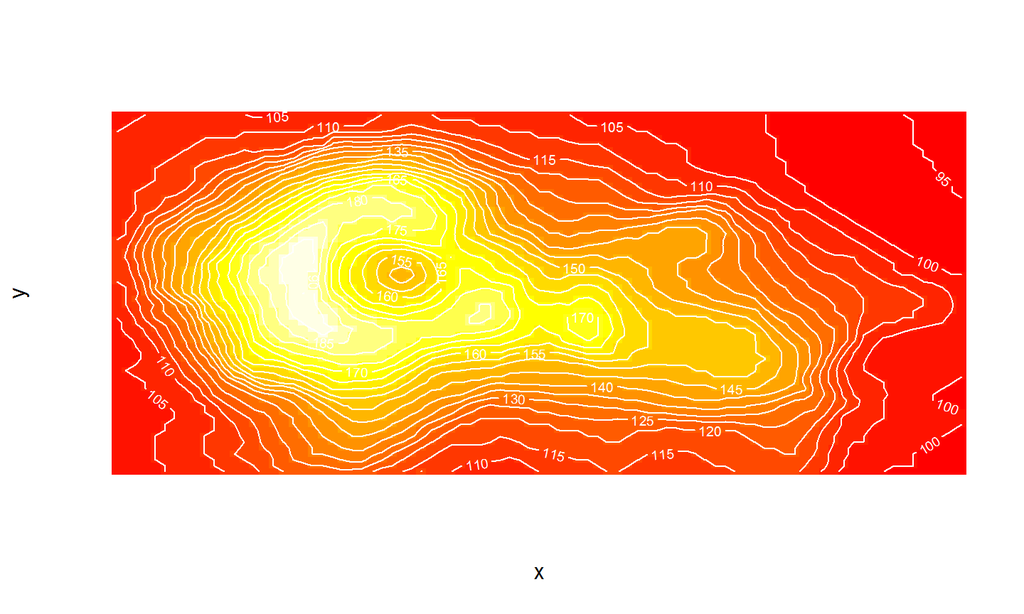

```r
x <- 10*(1:nrow(volcano))
y <- 10*(1:ncol(volcano))
image(x, y, volcano, col = heat.colors(20, alpha = 1), axes = FALSE)
contour(x, y, volcano, levels = seq(90, 200, by = 5),
        add = TRUE, col = 'white')
```

## grDevices, colorRamps Packages

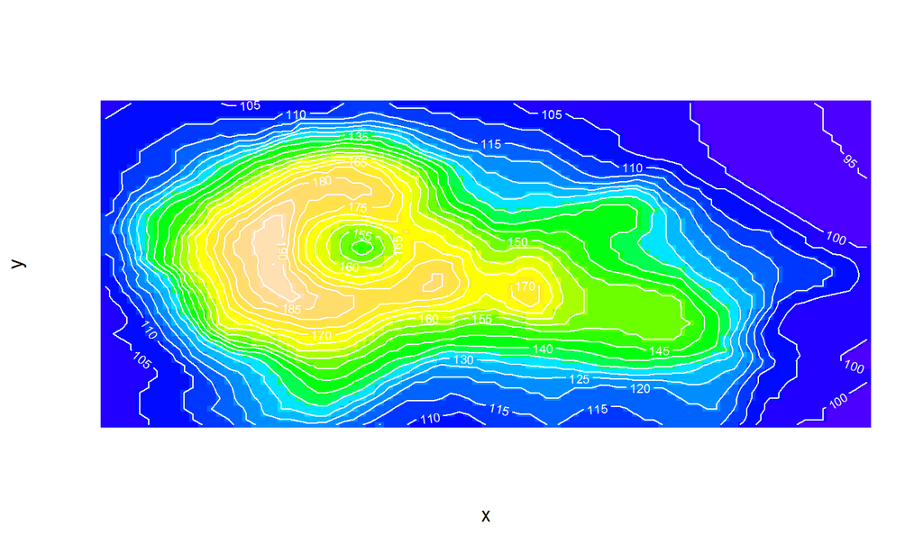

```r
x <- 10*(1:nrow(volcano))
y <- 10*(1:ncol(volcano))
image(x, y, volcano, col = topo.colors(20, alpha = 1), axes = FALSE)
contour(x, y, volcano, levels = seq(90, 200, by = 5),
        add = TRUE, col = 'white')
```

## grDevices, colorRamps Packages

- rainbow colors는 hsv color system을 기반으로 한다.
- n (색상의 수), s (채도), v (명도), start (h의 시작값), end (h의 끝값), alpha (투명도)
- 시작값과 끝값의 범위: 0 ~ 1

```r
rainbow(5, s = 0.4, v = 0.3, start = 0, end = 0.05, alpha = 1)
```

```
## [1] "#4D2E2EFF" "#4D302EFF" "#4D322EFF" "#4D352EFF" "#4D372EFF"
```

## RColorBrewer package

- 이 패키지를 사용하면 R에서 제공되는 palette들을 사용할 수 있다.
- sequential palettes : Blues, BuGn, BuPu, …, YlOrBr, YlOrRd

```r
if(!require(RColorBrewer)){install.packages("RColorBrewer"); library(RColorBrewer)}
brewer.pal(4, 'Blues')
```

```
## [1] "#EFF3FF" "#BDD7E7" "#6BAED6" "#2171B5"
```

## RColorBrewer package

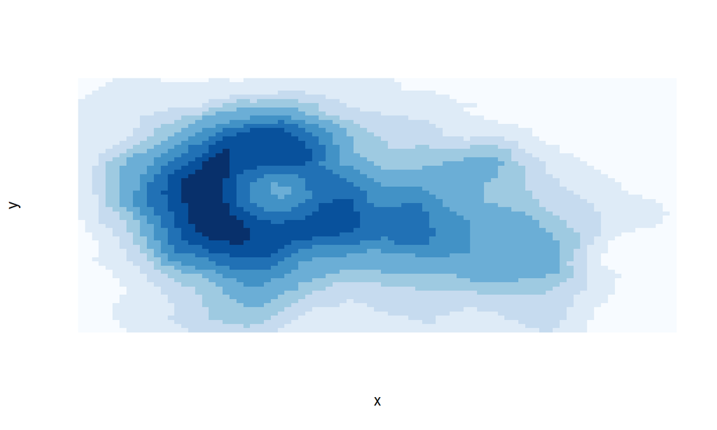

```r
x <- 10*(1:nrow(volcano))
y <- 10*(1:ncol(volcano))
image(x, y, volcano, col = brewer.pal(9, 'Blues'), axes = FALSE)
```

## RColorBrewer package

- Diverging palettes : BrBG, PiYG, .., RdYlGn, Spectral
- 가운데 색상들은 밝고, 시작과 끝의 색상은 어둡다.

```r
brewer.pal(4, 'BrBG')
```

```
## [1] "#A6611A" "#DFC27D" "#80CDC1" "#018571"
```

## RColorBrewer package

- display.brewer.all()
- RColorBrewer package에서 사용할 수 있는 palette들을 보여준다.

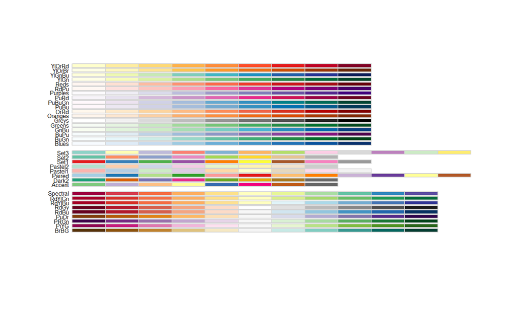

```r
display.brewer.all()
```

## colorspace package

- Color palettesms hcl, hsv color system을 기반으로 생성된다.
- diverge_hcv, diverge_hsl, terrain_hcl, sequential_hcl, rainbow_hcl, …

```r
if(!require(colorspace)){install.packages("colorspace"); library(colorspace)}
diverge_hcl(7, h = c(246, 40), c = 96, l = c(65, 90))
```

```
## [1] "#1FA4FF" "#97BFF3" "#CAD6E9" "#E2E2E2" "#E7D1C5" "#E9B18B" "#E28912"
```

## colorspace package

```r
pal = choose_palette()
```

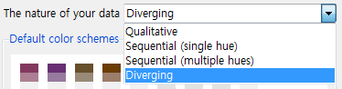

- Color palette들을 만들기 위한 Interactive tool이다.
- 옵션은 RColorBrewer에서 참고할 수 있다.

## colorspace package

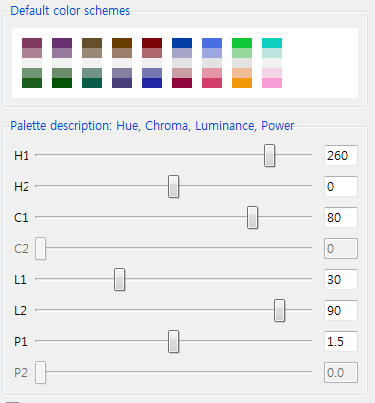

- 색상, 채도, 명도는 기본으로 선택되어 있다.
- hcl 또는 hsv에 대한 옵션으로 선택할 수 있다.

## colorspace package

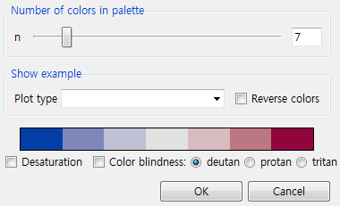

- 예시로 한번 해보세요.

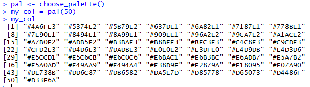